# HW3 Combined

The residuals show constant variance over time, and there is no significant autocorrelation structure that can be seen in the residuals. There may be is a bit of funneling of residuals at later periods but not to such an extent that we can confidently conclude presence of heteroscedacticity in the residuals.

Bartlett’s test overwhelmingly shows that the model has been reduced to white noise with a p-value of 0.9999.

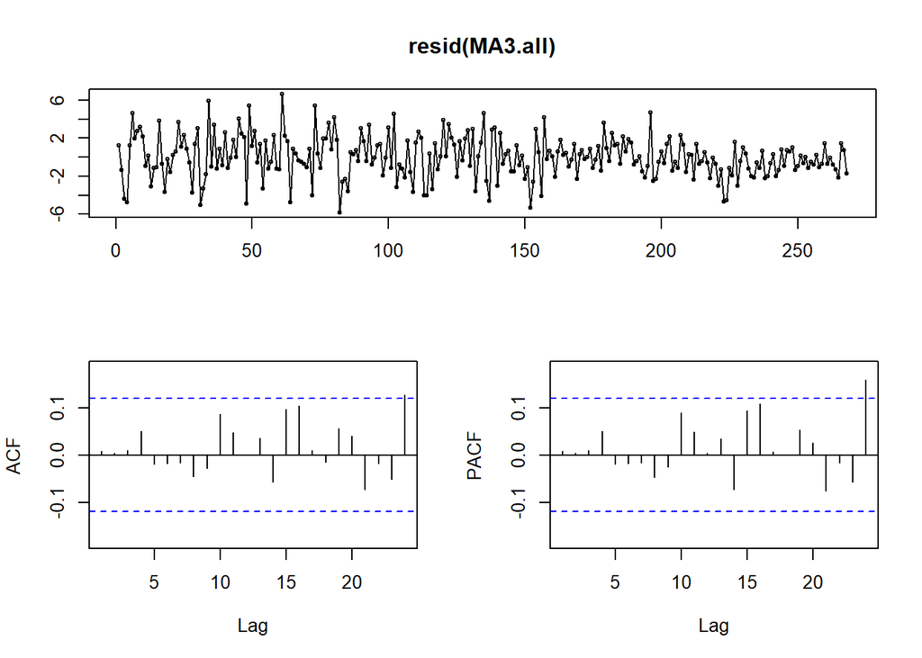

```r
forecast::tsdisplay(resid(MA3.all))
```

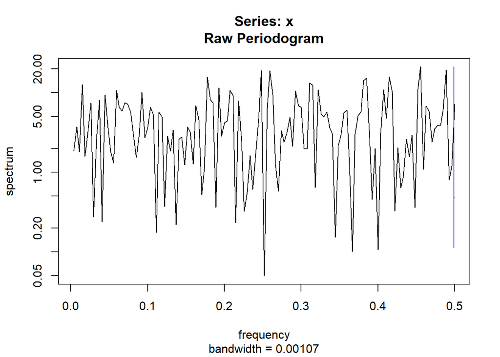

```r
spectrum(resid(MA3.all))
```

```r
bartlettB.test(ts(resid(MA3.all)))
```

```
##
##  Bartlett B Test for white noise
##
## data:
## = 0.33371, p-value = 0.9999
```

22. Find the zeros of the autoregressive polynomial for your model fit and interpret the results.

```r
coef(MA3)
```

```
##         ma1         ma2         ma3   intercept       jan58       oct65
##   0.1875751   0.3568942   0.2632198   3.7032337  -7.8517204   6.4354120
##       oct74       apr80
##  -9.1051376 -12.7052624
```

```r
coef(MA3.all)
```

```
##         ma1         ma2         ma3   intercept       jan58       oct65
##   0.2257209   0.3850609   0.2978763   3.3677438  -7.4515169   6.2100247
##       oct74       apr80
##  -8.9976004 -12.6660132
```

```r
delta<-c(rep(0,times=10))
delta[1]<-1
delta[2]<--0.2257209

for(j in 3:10){
j1<-j-1
j2<-j-2
delta[j]<-- 0.2257209*delta[j1]-0.3850609*delta[j2]
}

delta
```

```
##  [1]  1.000000000 -0.225720900 -0.334110975  0.162332123  0.092011320
##  [6] -0.083276631 -0.016632686  0.035820919 -0.001680933 -0.013413814
```

```r
# choosing delta[1:4] because MA(3) model has 3 coefficients
zeros<-1/polyroot(delta[1:4])
zeros
```

```
## [1]  0.4416851-0.2274888i -0.6576493-0.0000000i  0.4416851+0.2274888i
```

```r
#amplitude. Selecting zero with positive imaginary part.
Mod(zeros[3])
```

```
## [1] 0.4968268
```

```r
#period
2*pi/Arg(zeros)[3]
```

```
## [1] 13.21071
```

3. The quarterly percentage changes for 2020.1 to 2021.4 were −6.9, −33.4, 41.4, 3.4, 11.4, 12.0, 2.0, and 3.1. Comment briefly on the implications of these numbers.

**Discussion:** The introduction of these numbers to fit a model may lead to sub-optimal models. The four previously identified outliers are percentage changes of values of -5.4, 11.7, -5.7, and -8.7. If we use the same standard in selecting these outliers (less than -5 and greater than 10), then five percentage change values from 2020.1 to 2021.4 would classify as outliers (−6.9, −33.4, 41.4, 11.4, 12.0). Two values in particular, -33.4 and 41.4, are vastly different from anything we have seen from 1953.1 to 2019.4, where most percentage changes fall between -5.0 and 10.0. These numbers has the potential to distort the model fitted and should be excluded.